# Blog

# Plot

The trajectory would be easier to interpreter if we include more elements on the plot.  
To include the begging or the end of the trajectory identify the first and last location.

```r
GPS_first<-data.frame(Latitude=first(GPS_trip$Latitude),Longitude=first(GPS_trip$Longitude))
GPS_last<-data.frame(Latitude=last(GPS_trip$Latitude),Longitude=last(GPS_trip$Longitude))
```

Here, the first location is shown as the red triangle.  
The last location is is shown as the green square.

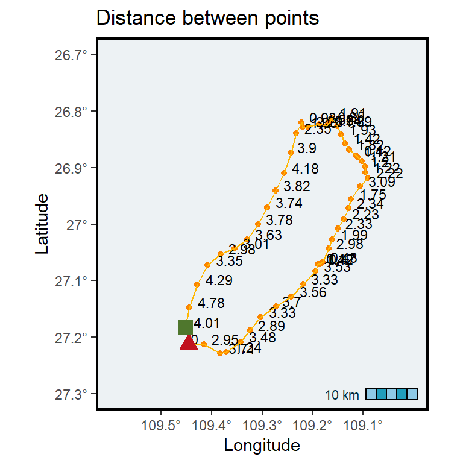

```r
Plot_distance<-ggplot(GPS_sf)+
  geom_sf()+
  geom_point(data=GPS_trip, aes(x=Longitude,y=Latitude),color='#fb8500')+
  geom_text(data=GPS_trip, aes(x=Longitude,y=Latitude,label=distances),hjust=-0.3, vjust=0, size=3)+
  geom_path(data=GPS_trip, aes(x=Longitude,y=Latitude),color='#ffb703')+
  annotation_scale(location = "br",bar_cols = c("#8ecae6", "#219ebc"),text_col = '#023047')+
  scale_x_continuous(limits=c(-109.6,-109.0),breaks=c(-109.5,-109.4,-109.3,-109.2,-109.1),labels = function(x) paste0(-x, '\u00B0')) +
  scale_y_continuous(limits=c(-27.3,-26.7),labels = function(x) paste0(-x, '\u00B0'))  +
  ggtitle('Distance between points')+xlab('Longitude')+ylab('Latitude')+
  theme_bw()+
  theme(
    legend.position='none',
    panel.background = element_rect(fill = '#edf2f4'),
    panel.grid.major = element_blank(),
    panel.grid.minor = element_blank(),
    panel.border = element_rect(colour = "black", fill=NA, size=1.5))+
  geom_point(data=GPS_first, aes(x=Longitude,y=Latitude),color='#c1121f',fill='#c1121f', shape=17, size=4)+
  geom_point(data=GPS_last, aes(x=Longitude,y=Latitude),color='#4f772d',fill='#4f772d',shape=15,size=4)
Plot_distance
```

# Further reading

The function **dist_points** from the package **sula** runs this function in loop.  
This helps when there are more than one trip and several individuals.

# Export

# ~~~~~~~~~~~~~

# 11.November

# Complete or Incomplete

# Intro

When tracking animals, there may be times when they enter areas with no reception.

If a large part of a trip takes place in such areas, you should consider whether to include this data in your calculations.

For instance, long gaps could lead to an underestimation of the actual distance traveled by the animal.

In this post, I’ll walk you through the steps I used to determine whether trips are complete or incomplete.

This post has three parts:  
- Create a gap  
- Calculate gaps  
- Identify if our trips are complete or incomplete

# Data

For the exercises, test data is from masked boobies.  
To access the data you have to install the package **sula**: devtools::install_github(“MiriamLL/sula”)

```r
library(sula)
```

Use the function select from tidyverse to keep the columns ID, latitude, longitude, date, time, and trip number.

```r
library(tidyverse)
Data_1original<-GPS_preparado %>% select(IDs,Latitude,Longitude,DateGMT,TimeGMT,trip_number)
```

# Creating a gap

In this part we would eliminate some locations to create an artificial gap

```r
library(sf)
```

Select a location with “low reception” and remove all the locations to create the gaps

```r
This_area<-data.frame(Longitude=-109.4,Latitude=-27.6)

create_buffer<-function(central_point=central_point, buffer_km=buffer_km){
  central_spatial<- sp::SpatialPoints(cbind(central_point$Longitude,central_point$Latitude))
  sp::proj4string(central_spatial)= sp::CRS("+init=epsg:4326")
  central_spatial <- sp::spTransform(central_spatial, sp::CRS("+init=epsg:4326"))
  central_spatial<-sf::st_as_sf(central_spatial)
  buffer_dist<-buffer_km*1000
  central_buffer<-sf::st_buffer(central_spatial, buffer_dist)
  return(central_buffer)
}

This_buffer<-create_buffer(central_point=This_area,buffer_km=20)

Data_2spatial <- Data_1original
sp::coordinates(Data_2spatial) <- ~Longitude + Latitude
sp::proj4string(Data_2spatial) = sp::CRS("+init=epsg:4326")
Data_2spatial <-sf::st_as_sf(Data_2spatial)
Data_3creategap<-sapply(sf::st_intersects(Data_2spatial ,This_buffer), function(z) if (length(z)==0) NA_integer_ else z[1])
Data_1original$trip <- as.numeric(Data_3creategap)
Data_4withgap <- Data_1original %>%
  filter(is.na(trip)==TRUE)
```

Plot the area with low reception

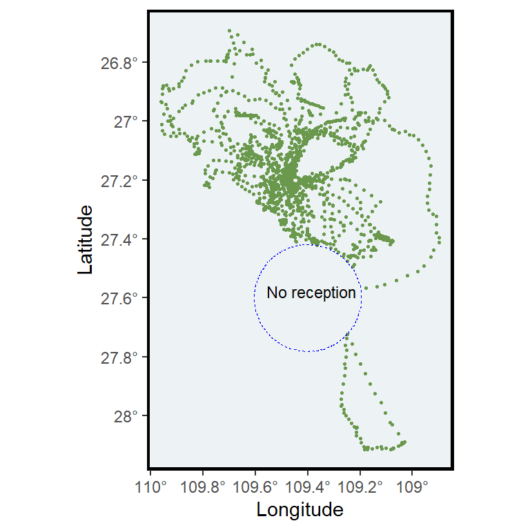

```r
Plot_locations<-ggplot()+
  geom_point(data = Data_4withgap,aes(x=Longitude,y = Latitude),color="#6a994e",size=0.5)+
  scale_x_continuous(labels = function(x) paste0(-x, '\u00B0')) +
  scale_y_continuous(labels = function(x) paste0(-x, '\u00B0'))  +
  xlab('Longitude')+ylab('Latitude')+
  theme(
    panel.background = element_rect(fill = '#edf2f4'),
    panel.grid.major = element_blank(),
    panel.grid.minor = element_blank(),legend.position='none',
    panel.border = element_rect(colour = "black", fill=NA, size=1.5))+
  geom_sf(data=This_buffer,colour='blue', fill='transparent', linetype='dashed')+
  geom_text(data=This_area, aes(x=Longitude,y=Latitude,label="No reception"),hjust=+0.46, vjust=0, size=3)
Plot_locations
```

# Calculate gaps

A column in the format POSIXct is needed for this example.

```r
Data_4withgap <- Data_4withgap %>%
  mutate(dt= as.POSIXct(strptime(paste0(DateGMT," ",TimeGMT), format="%d/%m/%Y %H:%M:%S")))
```

Checking gaps in time on one individual trip.

```r
Data_5oneindividual<-Data_4withgap %>% filter(IDs=='GPS09') %>% filter(trip_number=='trip_2')
```

```r
Data_5oneindividual<-Data_5oneindividual %>%
  mutate(times_lag=lag(dt))%>%
  mutate(time_dif=as.numeric(difftime(dt, times_lag, units = "mins")))%>%
  mutate(time_dif_mins = round(time_dif,2))
```

This trip has a large gap.

```r
range(Data_5oneindividual$time_dif_mins,na.rm=TRUE)
```

```
## [1]  4.07 57.70
```

Create a loop to calculate gaps separated by individuals and trips.

```r
calculate_gaps<-function (this_data = this_data,
                          column_datetime = column_datetime,
                          column_separator = column_separator){
  # to standardize the column names
  this_data$column_separator<- this_data[[column_separator]]
  this_data$column_datetime <- this_data[[column_datetime]]
  trips_list <- split(this_data, this_data$column_separator)
    gaps_list <- list()
    for (i in seq_along(trips_list)) {
        trip_df <- trips_list[[i]]
        trip_df<-trip_df %>%
          mutate(times_lag=lag(dt))%>%
          mutate(time_dif=as.numeric(difftime(dt, times_lag, units = "mins")))%>%
          mutate(time_dif_mins = round(time_dif,2))
        gaps_list[[i]] <- trip_df}
    gaps_df <- do.call("rbind", gaps_list)
    return(gaps_df)
}
```

For this, would help to have an unique ID, which helps separate the individual and their trips.

```r
Data_5uniqueIds <- Data_4withgap %>%
  mutate(unique_id=paste0(IDs,'_',trip_number))
```

To run the function, provide the data frame, the information for separating, and the name of the column where the date and time are provided.

```r
Data_6uniqueIds<-calculate_gaps(this_data=Data_5uniqueIds,
                                column_separator='unique_id',
                                column_datetime='dt')
```

# Complete or incomplete

By using the function summarise, we can see which trips have large gaps.

```r
Data_7gaps<-Data_6uniqueIds %>%
  group_by(unique_id)%>%
  summarise(min_gap=min(time_dif_mins,na.rm = TRUE),
            max_gap=max(time_dif_mins,na.rm = TRUE))
```

Based on the gaps during the trips, the trips could be classified as complete or incomplete.  
For example, here an incomplete trip would be any trip that had a gap of more than 30 minutes.

```r
Data_7gaps <- Data_7gaps%>%
  mutate(trip_class = case_when(max_gap <= 30 ~ 'Complete',
                                TRUE ~ 'Incomplete'))
```

Use this table to identify those trips that were incomplete.

```r
unique_incomplete<-unique((subset(Data_7gaps,Data_7gaps$trip_class=='Incomplete')$unique_id))
```

Use the information above, to add the classification on the tracking locations.

```r
Data_8gaps <- Data_6uniqueIds %>%
  mutate(trip_class = case_when(unique_id %in% unique_incomplete ~ 'Incomplete',
                                TRUE ~ 'Complete'))
```

Plot incomplete trips.

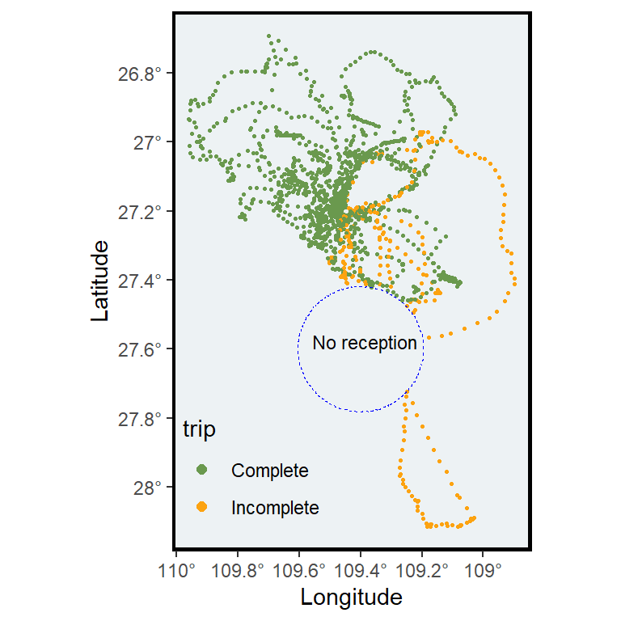

```r
Plot_trips<-ggplot()+
  geom_point(data = Data_8gaps,aes(x=Longitude,y = Latitude,color=trip_class),size=0.5)+
  scale_x_continuous(labels = function(x) paste0(-x, '\u00B0')) +
  scale_y_continuous(labels = function(x) paste0(-x, '\u00B0'))  +
  xlab('Longitude')+ylab('Latitude')+
  theme(
    panel.background = element_rect(fill = '#edf2f4'),
    panel.grid.major = element_blank(),
    panel.grid.minor = element_blank(),legend.position='none',
    panel.border = element_rect(colour = "black", fill=NA, size=1.5)
  )+
  geom_sf(data=This_buffer,colour='blue', fill='transparent', linetype='dashed')+
  geom_text(data=This_area, aes(x=Longitude,y=Latitude,label="No reception"),hjust=+0.46, vjust=0, size=3)+
  theme(
    legend.background = element_rect(colour = "transparent", fill = "transparent"),
    legend.position = c(0.22,0.15))+
  scale_colour_manual(name='trip',values = c("#6a994e", "#fca311"))+
  guides(color = guide_legend(override.aes = list(size = 2)))
Plot_trips
```

## Export

# ~~~~~~~~~~~~~

# 12.December

```r
library(sula)
```

```r
Data_1original<-GPS_preparado
```

# Transform

The function **fortify** helps the data frame to be more easily be plotted.

```r
library(tidyverse)
```

```r
Data_2fortify<-fortify(Data_1original)
```

Make sure your lat and lon are numerical

```r
Data_2fortify$lat<-as.numeric(Data_2fortify$Latitude)
Data_2fortify$lon<-as.numeric(Data_2fortify$Longitude)
```

Transform to spatial.

```r
library(sf)
```

Select which CRS you will like to use.

```r
Data_3spatial <- st_as_sf(Data_2fortify, coords = c("lon", "lat"),crs = 4326, agr = "constant")
```

Select the columns that are of interest.

```r
Data_4info<-Data_3spatial[,c("IDs","trip_number","dia_hora")]
```

# Map

Install the package **tmap**.

This package allows you to create interactive maps.

```r
library(tmap)
```

For making the map interactive, the mode **view** should be declared.

```r
tmap_mode("view")
```

```
## tmap mode set to interactive viewing
```

To create your map with points you can use the arguments **tm_shape** and **tm_dots**

```r
tm_shape(Data_4info)+
   tm_dots()
```

[interactive chart not shown]

To rename the information that shows, you can add the argument **popup.vars**

```r
tm_shape(Data_4info)+
   tm_dots(id = "IDs",col="yellow",popup.vars=c("trip_number"="trip_number","dt"="dia_hora"))
```

[interactive chart not shown]

To separate between individuals you can also include them as separated layers.

```r
tm_shape(subset(Data_4info,Data_4info$ID=='GPS01'))+
   tm_dots(id = "IDs",col="yellow",popup.vars=c("trip_number"="trip_number","dt"="dia_hora"))+
  tm_shape(subset(Data_4info,Data_4info$ID=='GPS03'))+
   tm_dots(id = "IDs",col="red",popup.vars=c("trip_number"="trip_number","dt"="dia_hora"))
```

[interactive chart not shown]

# Interact with you map

Using you can **zoom-in** to see the points.  
Using you can **zoom-out** to see the points.

Using you can select which **layers** to show.

Put the cursor on top of the dot , when appears click on it and you should be able to see the ID, trip number and dt and time of the point.

```r
tm_shape(subset(Data_4info,Data_4info$ID=='GPS01'))+
   tm_dots(id = "IDs",col="yellow",popup.vars=c("trip_number"="trip_number","dt"="dia_hora"))+
  tm_shape(subset(Data_4info,Data_4info$ID=='GPS03'))+
   tm_dots(id = "IDs",col="red",popup.vars=c("trip_number"="trip_number","dt"="dia_hora"))
```

[interactive chart not shown]

Using tmap might save you the step to export your dataframe, and the import it into another program, particularly if you want to check a particular point and particular information associated to that point.

# Further reading

- [tmap vignette](https://cran.r-project.org/web/packages/tmap/vignettes/tmap-getstarted.html)
- [examples of use](https://r-tmap.github.io/tmap/index.html)
- [book: Elegant and informative maps with tmap](https://r-tmap.github.io/tmap-book/index.html)
- [book: geocomputation with R](https://r.geocompx.org/adv-map)